# Measuring and analysing the causal impact of the Fukushima Daiichi nuclear disaster

```r
library(knitr)
```

```r
opts_chunk$set(comment=NA, fig.width=8, fig.height=6,cache=FALSE,self.contained=FALSE)
```

```r
library(rdd)
```

```r
library(ggplot2)
library(foreign)
library(AER)
```

## Data

```r
library(foreign)
try(setwd("C:/Users/Hackstutz/Dropbox/Fukushima/"))
try(setwd("C:/Users/rudi/Dropbox/Fukushima/"))
issp <- read.dta("issp_data/ZA5500_v2-0-0.dta")
```

For a few countries we have information about the month the interview took place but not the exact day. We suggest to impute these information using random uniform distributions.

```r
#random.org
set.seed(950075)

issp$randomDY <- NULL
howmany31 <- length(which(issp$DATEMO%in%c("January","March","May","July","August","October","December")))
howmany30 <- length(which(issp$DATEMO%in%c("April","June","September","November")))
howmany28 <- length(which(issp$DATEMO%in%c("February")))
# Plus cases missing DATEMO Sums to N (45199)

# Create random days that can be used to fill Missings
issp$randomDY[issp$DATEMO%in%c("January","March","May","July","August","October","December")]<-floor(runif(howmany31,1,32))
issp$randomDY[issp$DATEMO%in%c("April","June","September","November")]<-floor(runif(howmany30,1,31))
issp$randomDY[issp$DATEMO%in%c("February")]<-floor(runif(howmany28,1,29))

# Fill where the value of DATEDY is missing:
issp$DATEDY[is.na(issp$DATEDY)]<-issp$randomDY[is.na(issp$DATEDY)]

# Create a nice data variable
levels(issp$DATEYR) <- c("2009","2010","2011","No answer")
issp$datestring <- paste(issp$DATEYR,issp$DATEMO,issp$DATEDY,sep="-")
# Change the locale to apply strptime with english names for months
Sys.setlocale("LC_TIME","us")
```

```
[1] "English_United States.1252"
```

```r
issp$date <- strptime(issp$datestring,format="%Y-%B-%d")
#issp$V4[is.na(issp$date)] #6471 Missings

# dependent variable
issp$nuclear <- 5-as.numeric(issp$V45)
issp$nuclear[issp$nuclear%in%c("Can't choose","NA")] <- NA
issp$nuclear <- factor(issp$nuclear)

# independent variable: before/after fukushima
fukushima <- strptime("2011-03-13",format="%Y-%m-%d")
issp$after <- issp$date >= fukushima

# controls
issp$country <- issp$V4
issp$sex <- factor(issp$SEX)
issp$age <- issp$AGE/10
issp$old <- issp$age>4.7
# calculate standardized household income by country
issp$hhincome <- NA
for(i in which(names(issp)=="AT_INC"):which(names(issp)=="ZA_INC")) {
  issp$hhincome[!is.na(issp[,i])] <- scale(as.numeric(issp[!is.na(issp[,i]),i]))
}

issp$welloff <- issp$hhincome > 0
issp$educated <- issp$DEGREE%in%c("University degree completed, BG: lower tertiary level, upper tertiary level","University degree incomplete (qualifications above higher secondary level)","Higher secondary completed (usual entry requirements for universities)")
issp$trust <- (as.numeric(issp$V11)+as.numeric(issp$V12))/2
issp$pol_trust <-5-as.numeric(issp$V13)
```

It is important to know which countries contribute information to which period of time.

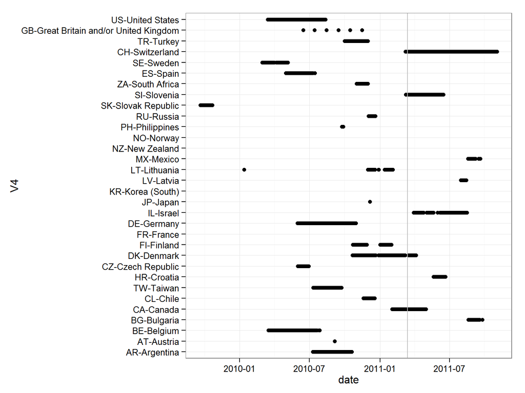

```r
library(ggplot2)

ggplot(issp, aes(x=date,y=V4))+geom_point()+geom_vline(xintercept=as.numeric(fukushima),color="gray")+theme_bw()
```

## Method

### Regression Discontinuity Design (RDD)

RDD’s causal identification strategy is to compare cases which are very close to a certain cutoff point of threshold which assigns data into a control and treatment group. Concerning the Fukushima accident, the assignment variable is time and the threshold is the day of the accident: 13th March 2011. Whether the interview was conducted before the 13th or after appears to be random so comparing individuals surveyed just before and just after the accident does control for most unobserved heterogeneity. RDD is illustrated in the following figure:

```
geom_smooth: method="auto" and size of largest group is <1000, so using loess. Use 'method = x' to change the smoothing method.
```

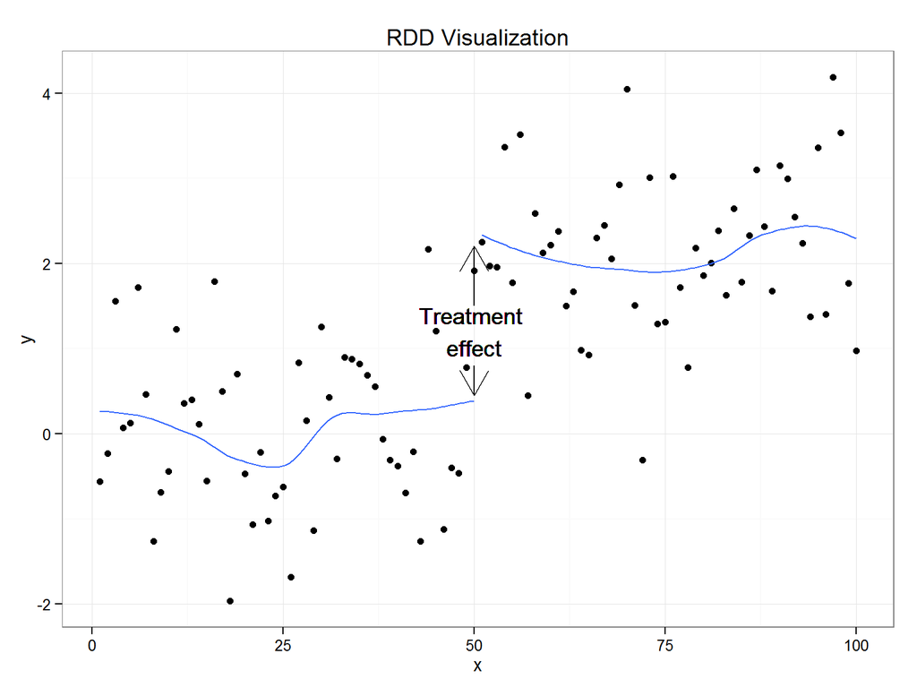

```r
library(ggplot2)
library(grid) #for function arrow()
x<-1:100
set.seed(123)
y<-rnorm(100)
y[50:100]<-y[50:100]+2
group<-c(rep(0,50),rep(1,50))
qplot(x,y,group=group) + stat_smooth(se=FALSE)+geom_text(show_guide=FALSE,x=50,y=1.2,label="Treatment \neffect",color="black")+geom_segment(aes(x = 50, y = 1.5, xend = 50, yend = 2.2), arrow = arrow(),color="black")+geom_segment(aes(x = 50, y = 0.8, xend = 50, yend = 0.45), arrow = arrow(),color="black")+ggtitle("RDD Visualization")+theme_bw()
```

### Difference-in-Difference Estimator (DiD)

DiD’s causal identification strategy is to get rid of multiple sources of unobserved heterogeneity by controlling for country-characteristics (country dummies) and period-characteristics (period dummies) which in our case is accomplished by estimating a Country-Fixed-Effects Modell including a “before/after-Fukushima-Dummy”. There are two key assumptions to mention. First, DiD assumes the timetrend of $y$, i.e. attitudes towards nuclear energy to be stable over time. Second, as there are countries which are completely before or completely after the accident, the covariance of all variables needs to be stable accross countries. (das müssen wir noch diskutieren). DiD is illustrated in the next figure:

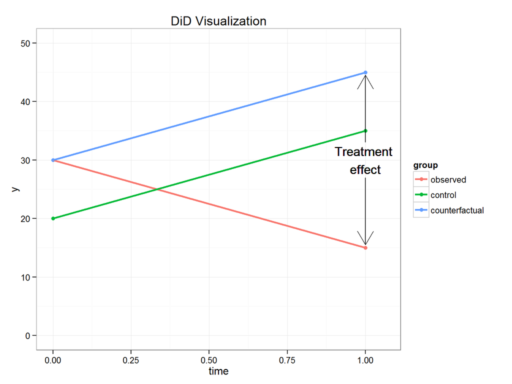

```r
time <- rep(c(0,1),3)
observed <- c(30,15)
control <- c(20,35)
counterfactual <- c(30,45)
group <- factor(c(1,1,2,2,3,3), labels=c("observed","control","counterfactual"))
y <- c(observed, control, counterfactual)
qplot(time,y,group=group, colour=group,ylim=c(0,50),xlim=c(0,1.06))+geom_line(size=1)+ggtitle("DiD Visualization")+geom_segment(aes(x = 1, y = 27, xend = 1, yend = 15.5), arrow = arrow(),color="black")+geom_segment(aes(x = 1, y = 33, xend = 1, yend = 44.5), arrow = arrow(),color="black")+geom_text(show_guide=FALSE,x=1,y=30,label="Treatment \neffect",color="black")+theme_bw()
```

## Models

### RDD

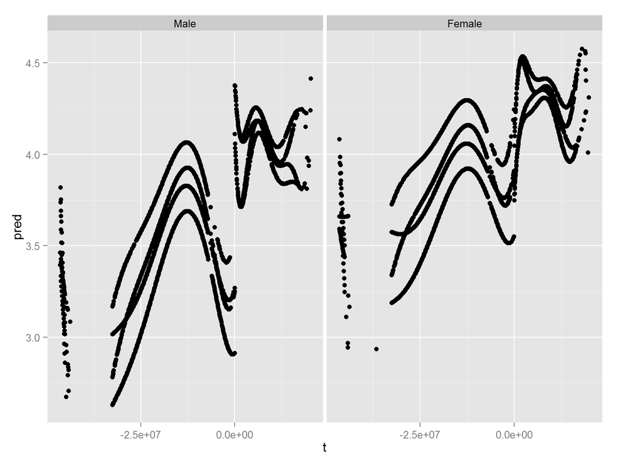

```r
issp$t <- as.numeric(issp$date)-as.numeric(fukushima)
# Exlude imputated Canadians:
issp$valid <- TRUE
issp$valid[issp$country=="CA-Canada"& issp$DATEMO=="March"] <- FALSE

fit_rd_param<-lm(as.numeric(nuclear)~after*(sex+old+educated)*(t+I(t^2)+I(t^3)+I(t^4)+I(t^5)+I(t^6)), data=subset(issp,valid==TRUE))
# interaction is significant for sex but not for old or educated
rd_data <- model.frame(fit_rd_param)
rd_data$pred <- predict(fit_rd_param)
ggplot(rd_data, aes(y=pred,x=t))+geom_point()+facet_wrap(~sex)
```

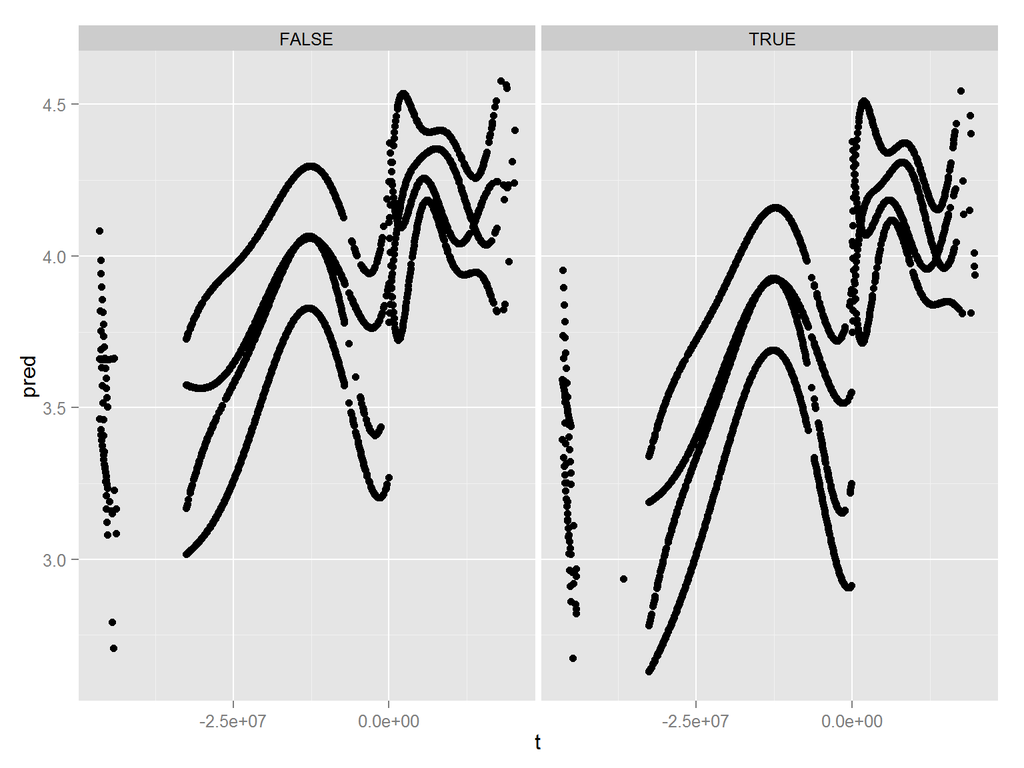

```r
ggplot(rd_data, aes(y=pred,x=t))+geom_point()+facet_wrap(~old)
```

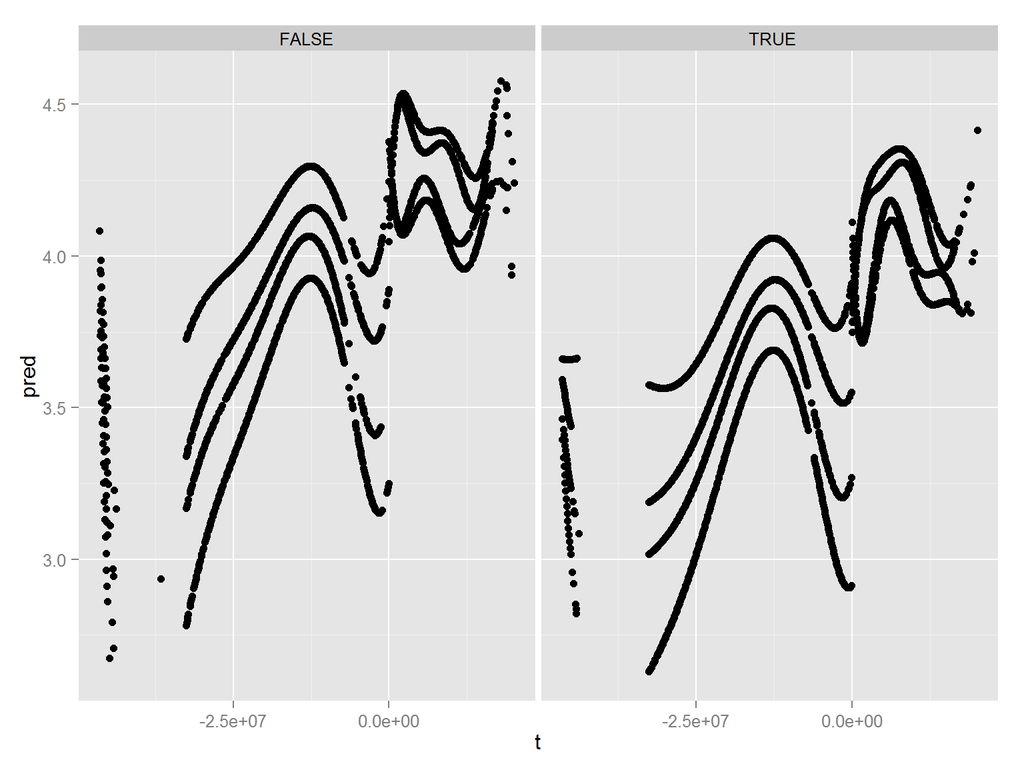

```r
ggplot(rd_data, aes(y=pred,x=t))+geom_point()+facet_wrap(~educated)
```

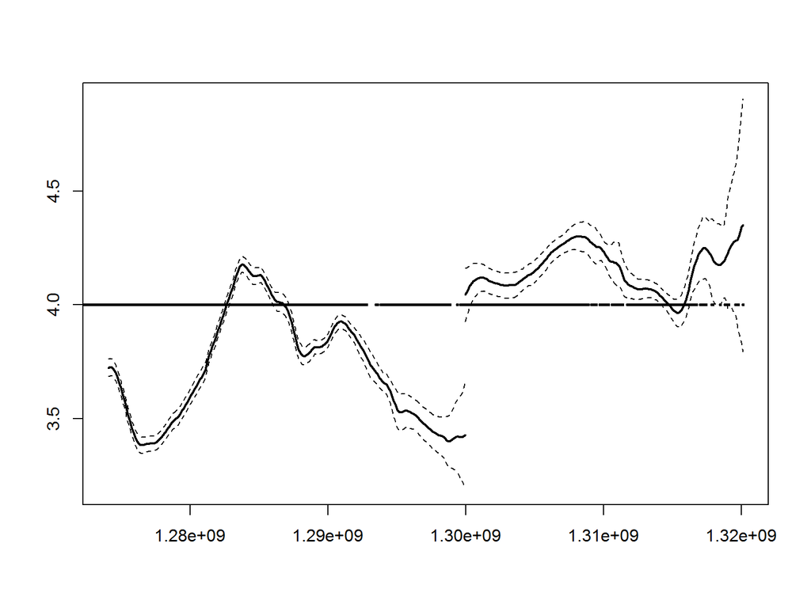

```r
library(rdd)
# Efficiency gains can be made by including covariates. I.e. country dummies. Austin Nicols stronly discourages that.
#RDestimate(as.numeric(nuclear)~as.numeric(date), cutpoint=as.numeric(fukushima),data=issp)
bw <- 86400*c(14,30,60,90) #86400 equals 1 day



fit_rd<-RDestimate(as.numeric(nuclear)~as.numeric(date), cutpoint=as.numeric(fukushima),data=subset(issp,valid==TRUE),bw=bw[2])

par(mfrow=c(1,1))
plot(fit_rd)
```

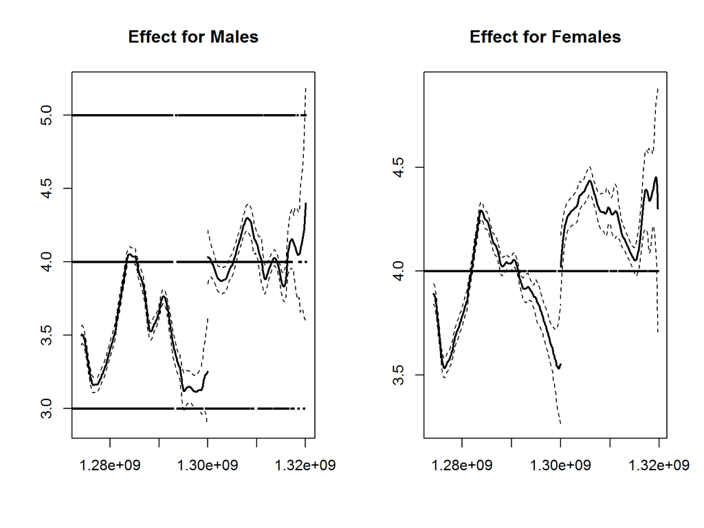

```r
# Split by Sex
fit_rd_male<-RDestimate(as.numeric(nuclear)~as.numeric(date), cutpoint=as.numeric(fukushima),data=subset(issp,sex=="Male"&valid==TRUE),bw=bw[2])
fit_rd_female<-RDestimate(as.numeric(nuclear)~as.numeric(date), cutpoint=as.numeric(fukushima),data=subset(issp,sex=="Female"&valid==TRUE),bw=bw[2])

par(mfrow=c(1,2))
plot(fit_rd_male)
title("Effect for Males")
plot(fit_rd_female)
title("Effect for Females")
```

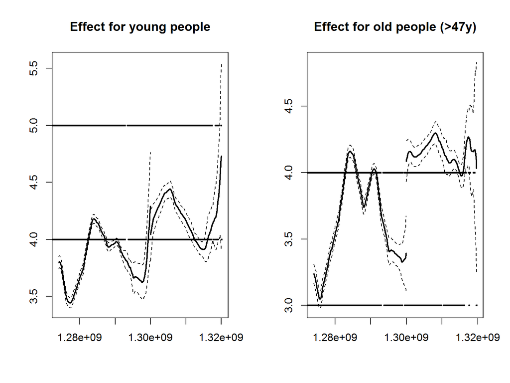

```r
# Split by Age (old means >47 years)
fit_rd_young<-RDestimate(as.numeric(nuclear)~as.numeric(date), cutpoint=as.numeric(fukushima),data=subset(issp,old==FALSE&valid==TRUE),bw=bw[2])
fit_rd_old<-RDestimate(as.numeric(nuclear)~as.numeric(date), cutpoint=as.numeric(fukushima),data=subset(issp,old==TRUE&valid==TRUE),bw=bw[2])

par(mfrow=c(1,2))
plot(fit_rd_young)
title("Effect for young people")
plot(fit_rd_old)
title("Effect for old people (>47y)")
```

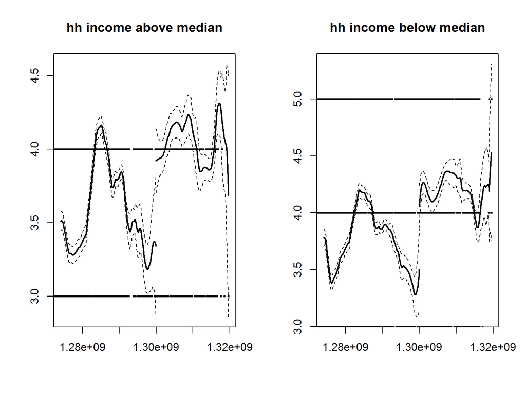

```r
# Split by income (above/below median)
fit_rd_welloff<-RDestimate(as.numeric(nuclear)~as.numeric(date), cutpoint=as.numeric(fukushima),data=subset(issp,welloff==TRUE&valid==TRUE),bw=bw[2])
fit_rd_notwell<-RDestimate(as.numeric(nuclear)~as.numeric(date), cutpoint=as.numeric(fukushima),data=subset(issp,welloff==FALSE&valid==TRUE),bw=bw[2])

par(mfrow=c(1,2))
plot(fit_rd_welloff)
title("hh income above median")
plot(fit_rd_notwell)
title("hh income below median")
```

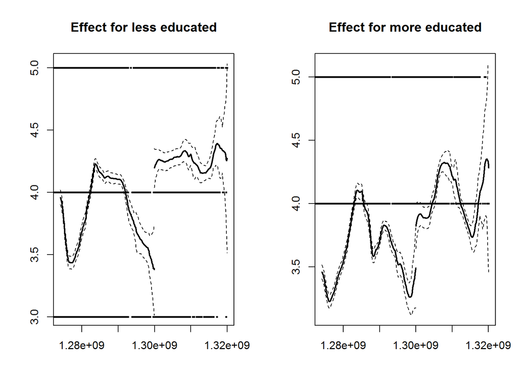

```r
# Split by education (qualified to enter university and higher)
fit_rd_uneduc<-RDestimate(as.numeric(nuclear)~as.numeric(date), cutpoint=as.numeric(fukushima),data=subset(issp,educated==FALSE&valid==TRUE),bw=bw[2])
fit_rd_educ<-RDestimate(as.numeric(nuclear)~as.numeric(date), cutpoint=as.numeric(fukushima),data=subset(issp,educated==TRUE&valid==TRUE),bw=bw[2])

par(mfrow=c(1,2))
plot(fit_rd_uneduc,ylim=c(3,5))
title("Effect for less educated")
plot(fit_rd_educ,ylim=c(3,5))
title("Effect for more educated")
```

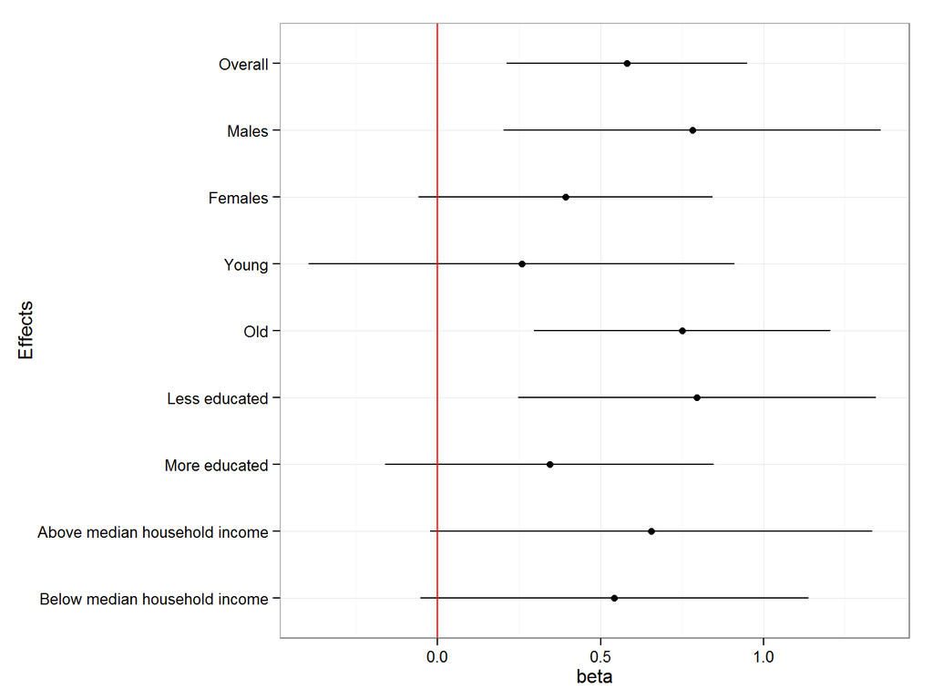

```r
# Table with all effects
betas30 <- c(fit_rd$est[1], fit_rd_male$est[1],fit_rd_female$est[1],fit_rd_young$est[1],fit_rd_old$est[1],fit_rd_uneduc$est[1],fit_rd_educ$est[1],fit_rd_welloff$est[1],fit_rd_notwell$est[1])
betas60 <- c(fit_rd$est[3], fit_rd_male$est[3],fit_rd_female$est[3],fit_rd_young$est[3],fit_rd_old$est[3],fit_rd_uneduc$est[3],fit_rd_educ$est[3],fit_rd_welloff$est[3],fit_rd_notwell$est[3])
coefnames <- c("Overall", "Males","Females","Young","Old","Less educated","More educated", "Above median household income","Below median household income")
se30 <-  c(fit_rd$se[1], fit_rd_male$se[1],fit_rd_female$se[1],fit_rd_young$se[1],fit_rd_old$se[1],fit_rd_uneduc$se[1],fit_rd_educ$se[1],fit_rd_welloff$se[1],fit_rd_notwell$se[1])
se60 <-  c(fit_rd$se[3], fit_rd_male$se[3],fit_rd_female$se[3],fit_rd_young$se[3],fit_rd_old$se[3],fit_rd_uneduc$se[3],fit_rd_educ$se[3],fit_rd_welloff$se[3],fit_rd_notwell$se[3])

order <- 9:1
min30 <- betas30-1.96*se30
max30 <- betas30+1.96*se30
min60 <- betas60-1.96*se30
max60 <- betas60+1.96*se30

res_data <- data.frame(coefnames,betas30,betas60,min30,max30,order,min60,max60)

ggplot(res_data, aes(y = betas30, ymin=min30, ymax=max30, x = reorder(coefnames,order))) + geom_pointrange() + coord_flip()+theme_bw()+scale_x_discrete("Effects")+scale_y_continuous("beta") + geom_hline(xintercept = 0, colour="red")
```

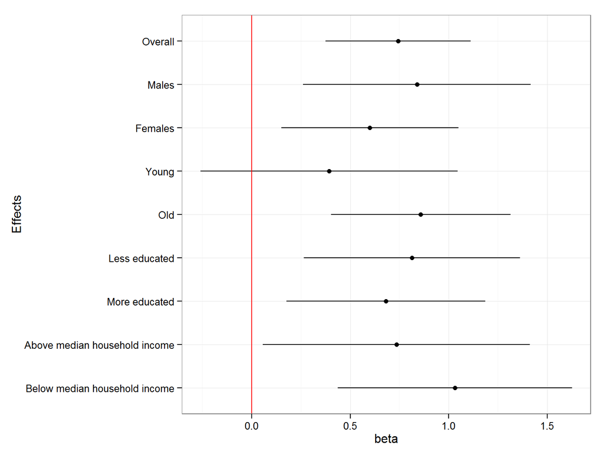

```r
ggplot(res_data, aes(y = betas60, ymin=min60, ymax=max60, x = reorder(coefnames,order))) + geom_pointrange() + coord_flip()+theme_bw()+scale_x_discrete("Effects")+scale_y_continuous("beta") + geom_hline(xintercept = 0, colour="red")
```

### DiD

Question: do we need ordered logit here because of potential compression effects (i.e. groups that had radical opinions BEFORE fukushima are not able to change there attitude. Image all women answered “very dangerous” before fukushima. then we can not observe an effect afterwards).

We can answer that with a simulation using plausible numbers (obtained from the later analyses)

```r
library(MASS)
woman <- rbinom(36342,1,0.5)
# introduce an effect for sex (-0.33) and after (-0.21) but no interaction
# also testet for the effects if nothing else is controlled for: sex=-0.348, after=-0.379
#b_sex <- -0.33
#b_after <- -0.21
b_sex <- -0.348
b_after <- -0.379

y_star <- woman*b_sex+rnorm(36342)
#retrieve cut-off-points
q20<-quantile(y_star,0.2)
q40<-quantile(y_star,0.4)
q60<-quantile(y_star,0.6)
q80<-quantile(y_star,0.8)
# introduce the fukushima effect
after <- rbinom(36342,1,0.5)
y_star <- y_star+b_after*after
y <- ifelse(y_star<q20,1,ifelse(y_star<q40,2,ifelse(y_star<q60,3,ifelse(y_star<q80,4,5))))
summary(lm(y~woman*after))
```

```
Call:
lm(formula = y ~ woman * after)

Residuals:
   Min     1Q Median     3Q    Max
 -2.24  -1.31  -0.24   1.25   2.69

Coefficients:
            Estimate Std. Error t value Pr(>|t|)
(Intercept)   3.2400     0.0143  226.40   <2e-16 ***
woman        -0.4914     0.0204  -24.11   <2e-16 ***
after        -0.5174     0.0202  -25.62   <2e-16 ***
woman:after   0.0760     0.0288    2.64   0.0083 **
---
Signif. codes:  0 '***' 0.001 '**' 0.01 '*' 0.05 '.' 0.1 ' ' 1

Residual standard error: 1.37 on 36338 degrees of freedom
Multiple R-squared:  0.0549,    Adjusted R-squared:  0.0548
F-statistic:  704 on 3 and 36338 DF,  p-value: <2e-16
```

```r
summary(polr(as.factor(y)~woman*after))
```

```
Re-fitting to get Hessian
```

```
Call:
polr(formula = as.factor(y) ~ woman * after)

Coefficients:
              Value Std. Error t value
woman       -0.6249     0.0265  -23.56
after       -0.6581     0.0263  -25.02
woman:after  0.0798     0.0374    2.14

Intercepts:
    Value   Std. Error t value
1|2  -1.714   0.021    -80.949
2|3  -0.737   0.020    -37.518
3|4   0.108   0.019      5.622
4|5   1.128   0.021     54.562

Residual Deviance: 113847.38
AIC: 113861.38
```

```r
# We need ordered logit regression here. Fixed effects can be achieved by including country-dummies.
library(MASS)
# including country dummies in polr() throws an error..
#summary(polr(nuclear~after*(sex+age), data=issp))

# using OLS vs ordered logit seems legit (see simulation)

# Model without interactions to get the gross effect
summary(lm(as.numeric(nuclear)~after+sex+age+DEGREE+trust+pol_trust+as.numeric(TOPBOT)+country+DATEMO*DATEYR, data=issp))
```

```
Call:
lm(formula = as.numeric(nuclear) ~ after + sex + age + DEGREE +
    trust + pol_trust + as.numeric(TOPBOT) + country + DATEMO *
    DATEYR, data = issp)

Residuals:
   Min     1Q Median     3Q    Max
-3.602 -0.650  0.069  0.792  2.513

Coefficients: (13 not defined because of singularities)
                                                                                       Estimate
(Intercept)                                                                             4.45624
afterTRUE                                                                               0.14780
sexFemale                                                                               0.29182
age                                                                                    -0.02723
DEGREELowest formal qualification                                                      -0.02082
DEGREEIntermediate secondary completed (qualifications above the lowest qualification)  0.01120
DEGREEHigher secondary completed (usual entry requirements for universities)           -0.05361
DEGREEUniversity degree incomplete (qualifications above higher secondary level)       -0.08776
DEGREEUniversity degree completed, BG: lower tertiary level, upper tertiary level      -0.17810
trust                                                                                  -0.06182
pol_trust                                                                              -0.04487
as.numeric(TOPBOT)                                                                     -0.01755
countryAT-Austria                                                                       0.35785
countryBE-Belgium                                                                      -0.67071
countryBG-Bulgaria                                                                     -0.09061
countryCA-Canada                                                                       -0.42221
countryCL-Chile                                                                         0.19826
countryTW-Taiwan                                                                       -0.40582
countryHR-Croatia                                                                       0.18346
countryCZ-Czech Republic                                                               -1.08397
countryDK-Denmark                                                                      -0.58197
countryFI-Finland                                                                      -0.53156
countryDE-Germany                                                                      -0.11016
countryIL-Israel                                                                        0.22168
countryJP-Japan                                                                        -0.65694
countryLV-Latvia                                                                        0.21979
countryLT-Lithuania                                                                    -0.32512
countryMX-Mexico                                                                        0.46937
countryPH-Philippines                                                                   0.13051
```

[output cut: 332 more lines]

```
DATEMOMay:DATEYR2011
DATEMOJune:DATEYR2011
DATEMOJuly:DATEYR2011
DATEMOAugust:DATEYR2011
DATEMOSeptember:DATEYR2011
DATEMOOctober:DATEYR2011
DATEMONovember:DATEYR2011
DATEMODecember:DATEYR2011
---
Signif. codes:  0 '***' 0.001 '**' 0.01 '*' 0.05 '.' 0.1 ' ' 1

Residual standard error: 1.01 on 32837 degrees of freedom
  (12302 observations deleted due to missingness)
Multiple R-squared:  0.167, Adjusted R-squared:  0.165
F-statistic:  111 on 59 and 32837 DF,  p-value: <2e-16
```

```r
# the overall effect is 0.15 on the 1-5 scale.

fit <- lm(as.numeric(nuclear)~after*(sex+age+DEGREE+trust+pol_trust+as.numeric(TOPBOT))+country+DATEMO*DATEYR, data=issp)
summary(fit)
```

```
Call:
lm(formula = as.numeric(nuclear) ~ after * (sex + age + DEGREE +
    trust + pol_trust + as.numeric(TOPBOT)) + country + DATEMO *
    DATEYR, data = issp)

Residuals:
   Min     1Q Median     3Q    Max
-3.631 -0.650  0.068  0.788  2.558

Coefficients: (13 not defined because of singularities)
                                                                                                  Estimate
(Intercept)                                                                                       4.522186
afterTRUE                                                                                        -0.184641
sexFemale                                                                                         0.308842
age                                                                                              -0.035875
DEGREELowest formal qualification                                                                -0.023762
DEGREEIntermediate secondary completed (qualifications above the lowest qualification)           -0.000114
DEGREEHigher secondary completed (usual entry requirements for universities)                     -0.053644
DEGREEUniversity degree incomplete (qualifications above higher secondary level)                 -0.072829
DEGREEUniversity degree completed, BG: lower tertiary level, upper tertiary level                -0.191680
trust                                                                                            -0.068754
pol_trust                                                                                        -0.038784
as.numeric(TOPBOT)                                                                               -0.021785
countryAT-Austria                                                                                 0.375962
countryBE-Belgium                                                                                -0.660827
countryBG-Bulgaria                                                                               -0.037641
countryCA-Canada                                                                                 -0.426457
countryCL-Chile                                                                                   0.187109
countryTW-Taiwan                                                                                 -0.402719
countryHR-Croatia                                                                                 0.203892
countryCZ-Czech Republic                                                                         -1.075634
countryDK-Denmark                                                                                -0.571106
countryFI-Finland                                                                                -0.525409
countryDE-Germany                                                                                -0.092221
countryIL-Israel                                                                                  0.228962
countryJP-Japan                                                                                  -0.647845
countryLV-Latvia                                                                                  0.243531
countryLT-Lithuania                                                                              -0.321590
countryMX-Mexico                                                                                  0.520262
countryPH-Philippines                                                                             0.126237
```

[output cut: 382 more lines]

```
DATEMOMay:DATEYR2011
DATEMOJune:DATEYR2011
DATEMOJuly:DATEYR2011
DATEMOAugust:DATEYR2011
DATEMOSeptember:DATEYR2011
DATEMOOctober:DATEYR2011
DATEMONovember:DATEYR2011
DATEMODecember:DATEYR2011
---
Signif. codes:  0 '***' 0.001 '**' 0.01 '*' 0.05 '.' 0.1 ' ' 1

Residual standard error: 1.01 on 32827 degrees of freedom
  (12302 observations deleted due to missingness)
Multiple R-squared:  0.168, Adjusted R-squared:  0.166
F-statistic:   96 on 69 and 32827 DF,  p-value: <2e-16
```

```r
# controlling for country trends does not affect our results
fit2<-lm(as.numeric(nuclear)~after*(sex+age+DEGREE+trust+pol_trust)+country+DATEMO*DATEYR+country:as.numeric(date), data=issp)
summary(fit2)
```

```
Call:
lm(formula = as.numeric(nuclear) ~ after * (sex + age + DEGREE +
    trust + pol_trust) + country + DATEMO * DATEYR + country:as.numeric(date),
    data = issp)

Residuals:
   Min     1Q Median     3Q    Max
-3.684 -0.654  0.067  0.788  2.642

Coefficients: (15 not defined because of singularities)
                                                                                                  Estimate
(Intercept)                                                                                       3.46e+01
afterTRUE                                                                                         1.86e-02
sexFemale                                                                                         3.17e-01
age                                                                                              -3.55e-02
DEGREELowest formal qualification                                                                -2.18e-02
DEGREEIntermediate secondary completed (qualifications above the lowest qualification)           -8.40e-03
DEGREEHigher secondary completed (usual entry requirements for universities)                     -7.23e-02
DEGREEUniversity degree incomplete (qualifications above higher secondary level)                 -8.92e-02
DEGREEUniversity degree completed, BG: lower tertiary level, upper tertiary level                -2.15e-01
trust                                                                                            -7.29e-02
pol_trust                                                                                        -3.99e-02
countryAT-Austria                                                                                -3.02e+01
countryBE-Belgium                                                                                 3.25e+01
countryBG-Bulgaria                                                                               -1.85e+01
countryCA-Canada                                                                                  1.02e+02
countryCL-Chile                                                                                  -2.02e+02
countryTW-Taiwan                                                                                 -6.13e+01
countryHR-Croatia                                                                                -4.54e+01
countryCZ-Czech Republic                                                                         -2.01e+02
countryDK-Denmark                                                                                -1.07e+02
countryFI-Finland                                                                                -5.83e+01
countryDE-Germany                                                                                -5.79e+01
countryIL-Israel                                                                                  4.36e+01
countryJP-Japan                                                                                  -3.09e+01
countryLV-Latvia                                                                                  6.45e+01
countryLT-Lithuania                                                                              -4.08e+01
countryMX-Mexico                                                                                 -1.01e+02
countryPH-Philippines                                                                            -1.05e+02
countryRU-Russia                                                                                  6.89e+01
```

[output cut: 517 more lines]

```
countrySI-Slovenia:as.numeric(date)
countryZA-South Africa:as.numeric(date)
countryES-Spain:as.numeric(date)                                                                 .
countrySE-Sweden:as.numeric(date)
countryCH-Switzerland:as.numeric(date)
countryTR-Turkey:as.numeric(date)                                                                **
countryGB-Great Britain and/or United Kingdom:as.numeric(date)
countryUS-United States:as.numeric(date)
---
Signif. codes:  0 '***' 0.001 '**' 0.01 '*' 0.05 '.' 0.1 ' ' 1

Residual standard error: 1.01 on 34465 degrees of freedom
  (10639 observations deleted due to missingness)
Multiple R-squared:  0.174, Adjusted R-squared:  0.172
F-statistic: 77.5 on 94 and 34465 DF,  p-value: <2e-16
```

```r
# only use countries that include both: before and after measure
fit3<-lm(as.numeric(nuclear)~after*(sex+age+DEGREE+trust+pol_trust)+country+DATEMO*DATEYR+country:as.numeric(date), data=subset(issp,country%in%c("CH-Switzerland","SI-Slovenia","DK-Denmark","CA-Canada")))
summary(fit3)
```

```
Call:
lm(formula = as.numeric(nuclear) ~ after * (sex + age + DEGREE +
    trust + pol_trust) + country + DATEMO * DATEYR + country:as.numeric(date),
    data = subset(issp, country %in% c("CH-Switzerland", "SI-Slovenia",
        "DK-Denmark", "CA-Canada")))

Residuals:
   Min     1Q Median     3Q    Max
-3.512 -0.750  0.048  0.837  2.585

Coefficients: (10 not defined because of singularities)
                                                                                                  Estimate
(Intercept)                                                                                       1.04e+02
afterTRUE                                                                                        -4.47e-01
sexFemale                                                                                         7.25e-01
age                                                                                              -5.32e-02
DEGREELowest formal qualification                                                                -1.11e-01
DEGREEIntermediate secondary completed (qualifications above the lowest qualification)           -3.06e-01
DEGREEHigher secondary completed (usual entry requirements for universities)                     -4.99e-01
DEGREEUniversity degree incomplete (qualifications above higher secondary level)                 -5.27e-01
DEGREEUniversity degree completed, BG: lower tertiary level, upper tertiary level                -7.38e-01
trust                                                                                            -8.77e-02
pol_trust                                                                                        -4.64e-02
countryDK-Denmark                                                                                -2.06e+02
countrySI-Slovenia                                                                               -1.52e+02
countryCH-Switzerland                                                                            -1.38e+02
DATEMOFebruary                                                                                   -5.53e-01
DATEMOMarch                                                                                      -3.03e-01
DATEMOApril                                                                                      -3.59e-01
DATEMOMay                                                                                        -5.17e-01
DATEMOJune                                                                                       -4.91e-01
DATEMOJuly                                                                                       -5.56e-01
DATEMOAugust                                                                                     -9.18e-01
DATEMOSeptember                                                                                  -7.26e-01
DATEMOOctober                                                                                    -7.63e-01
DATEMONovember                                                                                   -7.96e-01
DATEMODecember                                                                                   -1.15e+00
DATEYR2011                                                                                       -1.15e+00
afterTRUE:sexFemale                                                                              -4.06e-01
afterTRUE:age                                                                                     6.93e-02
```

[output cut: 218 more lines]

```
DATEMOSeptember:DATEYR2011
DATEMOOctober:DATEYR2011
DATEMONovember:DATEYR2011
DATEMODecember:DATEYR2011
countryCA-Canada:as.numeric(date)                                                                .
countryDK-Denmark:as.numeric(date)                                                               .
countrySI-Slovenia:as.numeric(date)
countryCH-Switzerland:as.numeric(date)
---
Signif. codes:  0 '***' 0.001 '**' 0.01 '*' 0.05 '.' 0.1 ' ' 1

Residual standard error: 1.05 on 4140 degrees of freedom
  (404 observations deleted due to missingness)
Multiple R-squared:  0.193, Adjusted R-squared:  0.185
F-statistic: 25.3 on 39 and 4140 DF,  p-value: <2e-16
```

```r
# test social desirability
summary(lm(as.numeric(nuclear)~as.numeric(after)*MODE+country+DATEMO*DATEYR+country:as.numeric(date), data=issp))
```

```
Call:
lm(formula = as.numeric(nuclear) ~ as.numeric(after) * MODE +
    country + DATEMO * DATEYR + country:as.numeric(date), data = issp)

Residuals:
   Min     1Q Median     3Q    Max
-3.841 -0.626  0.046  0.789  2.144

Coefficients: (32 not defined because of singularities)
                                                                                Estimate
(Intercept)                                                                    -1.30e+02
as.numeric(after)                                                               1.17e-01
MODEF2F, PAPI, visuals                                                         -3.88e-02
MODEF2F, PAPI, respondent reading questionnaire                                 1.61e+02
MODEF2F, PAPI, interpreter or translator, no visuals                           -1.43e-03
MODEF2F, PAPI, interpreter or translator, visuals                               8.77e+01
MODECAPI, no visuals                                                            1.02e+02
MODECAPI, visuals                                                               1.46e+02
MODECAPI, respondent reading questionnaire                                      1.34e+02
MODESC, arrives with interviewer, interviewer attendg                           1.08e+02
MODESC, arrives with interviewer, drops-off, picks up later                     1.08e+02
MODESC, arrives with interviewer, drops-off,mailed back by R                    1.08e+02
MODESC, mailed back by R                                                        1.03e+02
MODECASI, self-completion, computer assisted                                    1.02e+02
MODEUS: CAPI, phone                                                             1.46e+02
countryAT-Austria                                                                     NA
countryBE-Belgium                                                               8.32e+01
countryBG-Bulgaria                                                              1.59e+02
countryCA-Canada                                                                1.04e+02
countryCL-Chile                                                                 5.76e+01
countryTW-Taiwan                                                                9.88e+01
countryHR-Croatia                                                               1.47e+02
countryCZ-Czech Republic                                                       -6.76e+01
countryFI-Finland                                                               2.89e+01
countryDE-Germany                                                              -1.11e+00
countryIL-Israel                                                                2.18e+02
countryJP-Japan                                                                 2.49e+01
countryLV-Latvia                                                                2.07e+02
countryLT-Lithuania                                                             4.48e+01
countryMX-Mexico                                                                1.22e+01
```

[output cut: 546 more lines]

```
countrySI-Slovenia:as.numeric(date)
countryZA-South Africa:as.numeric(date)
countryES-Spain:as.numeric(date)
countrySE-Sweden:as.numeric(date)
countryCH-Switzerland:as.numeric(date)
countryTR-Turkey:as.numeric(date)                                              **
countryGB-Great Britain and/or United Kingdom:as.numeric(date)
countryUS-United States:as.numeric(date)
---
Signif. codes:  0 '***' 0.001 '**' 0.01 '*' 0.05 '.' 0.1 ' ' 1

Residual standard error: 1.02 on 35261 degrees of freedom
  (9854 observations deleted due to missingness)
Multiple R-squared:  0.141, Adjusted R-squared:  0.139
F-statistic: 69.6 on 83 and 35261 DF,  p-value: <2e-16
```

```r
library(survey)# contains regTermTest for F-test
regTermTest(fit,"after:DEGREE")
```

```
Wald test for after:DEGREE
 in lm(formula = as.numeric(nuclear) ~ after * (sex + age + DEGREE +
    trust + pol_trust + as.numeric(TOPBOT)) + country + DATEMO *
    DATEYR, data = issp)
F =  1.736  on  5  and  32827  df: p= 0.12
```

```r
regTermTest(fit2,"after:DEGREE")#no interaction with education
```

```
Wald test for after:DEGREE
 in lm(formula = as.numeric(nuclear) ~ after * (sex + age + DEGREE +
    trust + pol_trust) + country + DATEMO * DATEYR + country:as.numeric(date),
    data = issp)
F =  1.535  on  5  and  34465  df: p= 0.18
```

```r
# to present the results it is easier to show two interaction effects instead of main effect plus interaction:
issp$before <- issp$after==FALSE
fit_final<-lm(as.numeric(nuclear)~as.numeric(before):(as.numeric(sex)+age+DEGREE+trust+pol_trust+hhincome)+as.numeric(after):(as.numeric(sex)+age+DEGREE+trust+pol_trust+hhincome)+country+DATEMO*DATEYR+country:as.numeric(date), data=issp)

# test interactions
library(AER)
coeftest(lm(as.numeric(nuclear)~as.numeric(after)*(as.numeric(sex)+age+DEGREE+trust+pol_trust+hhincome)+country+DATEMO*DATEYR+country:as.numeric(date), data=issp))[1:2,]
```

```
                  Estimate Std. Error t value  Pr(>|t|)
(Intercept)        4.20282     0.2753 15.2659 2.207e-52
as.numeric(after)  0.08604     0.1834  0.4691 6.390e-01
```

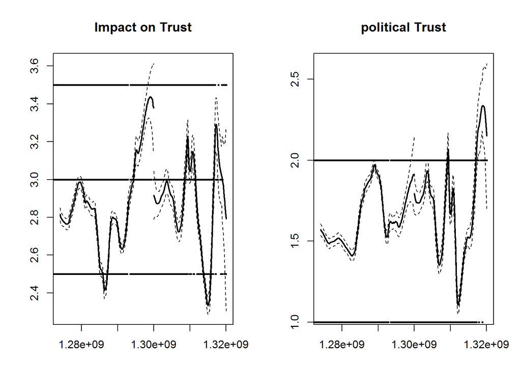

```r
#test endogeneity of trust
bw <- 86400*c(14,30,60,90) #86400 equals 1 day
fit_rd_trust<-RDestimate(as.numeric(trust)~as.numeric(date), cutpoint=as.numeric(fukushima),data=subset(issp,valid==TRUE),bw=bw[2])
fit_rd_poltrust<-RDestimate(as.numeric(pol_trust)~as.numeric(date), cutpoint=as.numeric(fukushima),data=subset(issp,valid==TRUE),bw=bw[2])
par(mfrow=c(1,2))
plot(fit_rd_trust)
title("Impact on Trust")
plot(fit_rd_poltrust)
title("political Trust")
```

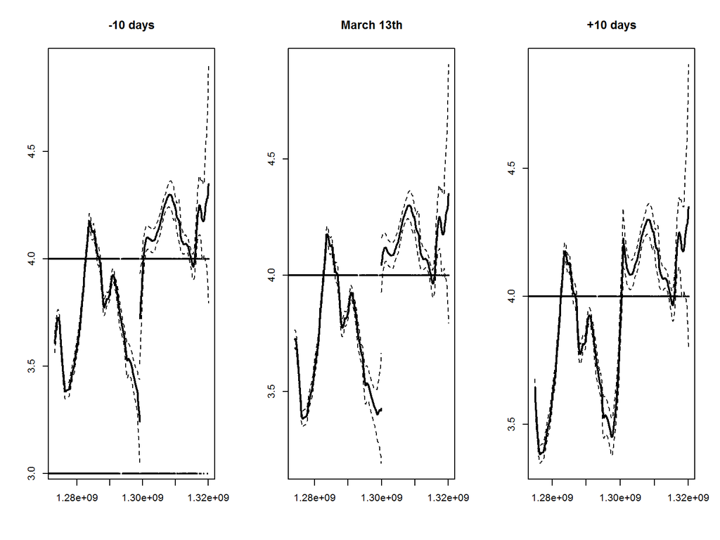

```r
# robustness check: shifting 10 days left and right
fit_rd_left<-RDestimate(as.numeric(nuclear)~as.numeric(date), cutpoint=as.numeric(fukushima-10*3600*24),data=subset(issp,valid==TRUE),bw=bw[2])
fit_rd_right<-RDestimate(as.numeric(nuclear)~as.numeric(date), cutpoint=as.numeric(fukushima+10*3600*24),data=subset(issp,valid==TRUE),bw=bw[2])
fit_rd<-RDestimate(as.numeric(nuclear)~as.numeric(date), cutpoint=as.numeric(fukushima),data=subset(issp,valid==TRUE),bw=bw[2])
par(mfrow=c(1,3))
plot(fit_rd_left)
title("-10 days")
plot(fit_rd)
title("March 13th")
plot(fit_rd_right)
title("+10 days")
```

```r
# because of our strong assumptions (metric Y) we should use robust standard errors
results<-coeftest(fit_final, vcov=vcovHC(fit_final,type="HC0"))
results
```

```
t test of coefficients:

                                                                                                           Estimate
(Intercept)                                                                                                4.20e+00
countryBE-Belgium                                                                                          8.90e+01
countryBG-Bulgaria                                                                                        -3.88e+01
countryCA-Canada                                                                                           1.71e+02
countryCL-Chile                                                                                           -2.38e+02
countryTW-Taiwan                                                                                          -3.30e+01
countryHR-Croatia                                                                                         -1.76e+01
countryCZ-Czech Republic                                                                                  -2.65e+02
countryDK-Denmark                                                                                         -8.58e+01
countryFI-Finland                                                                                         -2.50e+01
countryDE-Germany                                                                                         -2.25e+01
countryIL-Israel                                                                                           4.75e+01
countryJP-Japan                                                                                           -7.48e-01
countryLV-Latvia                                                                                           1.79e+02
countryLT-Lithuania                                                                                        2.49e+00
countryMX-Mexico                                                                                          -4.75e+00
countryPH-Philippines                                                                                     -1.79e+02
countryRU-Russia                                                                                           5.48e+01
countrySK-Slovak Republic                                                                                 -1.97e+02
countrySI-Slovenia                                                                                        -8.18e+01
countryZA-South Africa                                                                                    -1.47e+01
countryES-Spain                                                                                            6.05e+01
countrySE-Sweden                                                                                           5.88e+01
countryCH-Switzerland                                                                                     -4.45e+01
countryTR-Turkey                                                                                          -1.21e+02
countryGB-Great Britain and/or United Kingdom                                                             -7.59e+00
countryUS-United States                                                                                    4.27e+01
DATEMOFebruary                                                                                            -7.87e-01
DATEMOMarch                                                                                               -3.29e-01
DATEMOApril                                                                                               -4.02e-01
DATEMOMay                                                                                                 -5.17e-01
DATEMOJune                                                                                                -5.71e-01
DATEMOJuly                                                                                                -7.62e-01
DATEMOAugust                                                                                              -8.19e-01
DATEMOSeptember                                                                                           -9.38e-01
DATEMOOctober                                                                                             -9.05e-01
DATEMONovember                                                                                            -9.50e-01
```

[output cut: 424 more lines]

```
countryLT-Lithuania:as.numeric(date)
countryMX-Mexico:as.numeric(date)
countryPH-Philippines:as.numeric(date)
countryRU-Russia:as.numeric(date)
countrySK-Slovak Republic:as.numeric(date)
countrySI-Slovenia:as.numeric(date)                                                                       *
countryZA-South Africa:as.numeric(date)
countryES-Spain:as.numeric(date)
countrySE-Sweden:as.numeric(date)
countryCH-Switzerland:as.numeric(date)
countryTR-Turkey:as.numeric(date)                                                                         **
countryGB-Great Britain and/or United Kingdom:as.numeric(date)
countryUS-United States:as.numeric(date)
---
Signif. codes:  0 '***' 0.001 '**' 0.01 '*' 0.05 '.' 0.1 ' ' 1
```

### Plotting the results

We controlled for country levels, period dummies (monthly) and linear time trends within each country

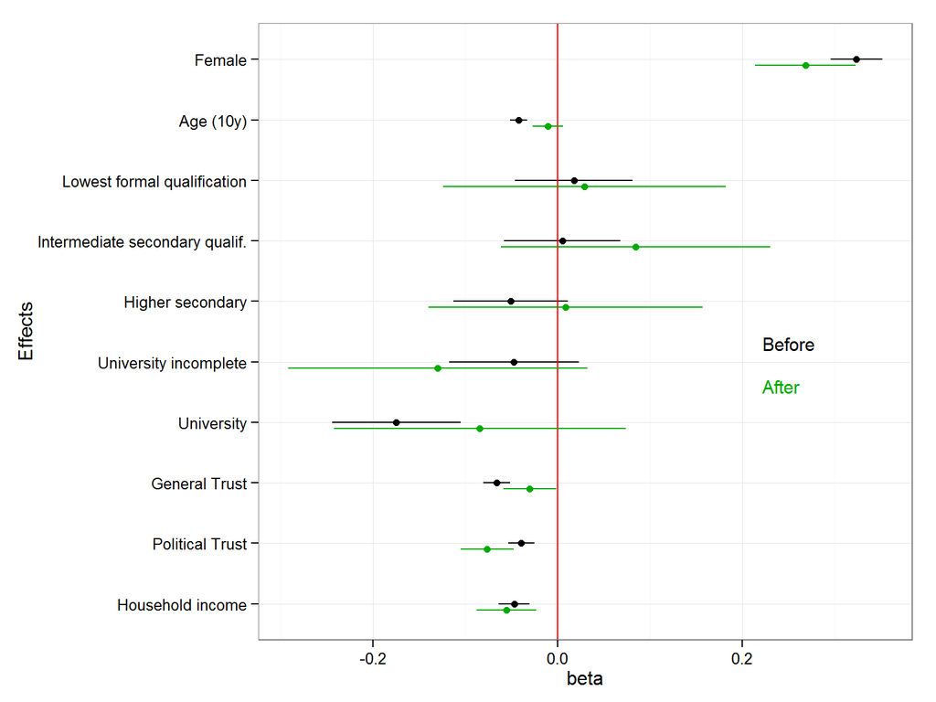

```r
coefnames <- c("Female","Age (10y)","Lowest formal qualification","Intermediate secondary qualif.","Higher secondary","University incomplete","University","General Trust","Political Trust", "Household income")
maineffects <- results[c(40:49),1]
interactions <- results[c(50:59),1]
main_se <- results[c(40:49),2]
int_se <- results[c(50:59),2]
order <- 10:1
main_min <- maineffects-1.96*main_se
main_max <- maineffects+1.96*main_se
int_min <- interactions-1.96*int_se
int_max <- interactions+1.96*int_se

res_data <- data.frame(coefnames,maineffects,interactions,main_se,int_se,order,main_min,main_max,int_min,int_max)

ggplot(res_data, aes(y = maineffects, ymin=main_min, ymax=main_max, x = reorder(coefnames,order))) + geom_pointrange() + coord_flip()+theme_bw()+scale_x_discrete("Effects")+scale_y_continuous("beta") + geom_hline(xintercept = 0, colour="red") + geom_pointrange(aes(y=interactions,ymin=int_min,ymax=int_max,x=as.numeric(reorder(coefnames,order))-0.1),colour="#00AA00") + annotate("text", x = 5.3, y = 0.25, label = "Before", colour = "black", size=4) + annotate("text", x = 4.6, y = 0.242, label = "After", colour = "#00AA00", size=4)
```